# Predictive Models Take Home Exam

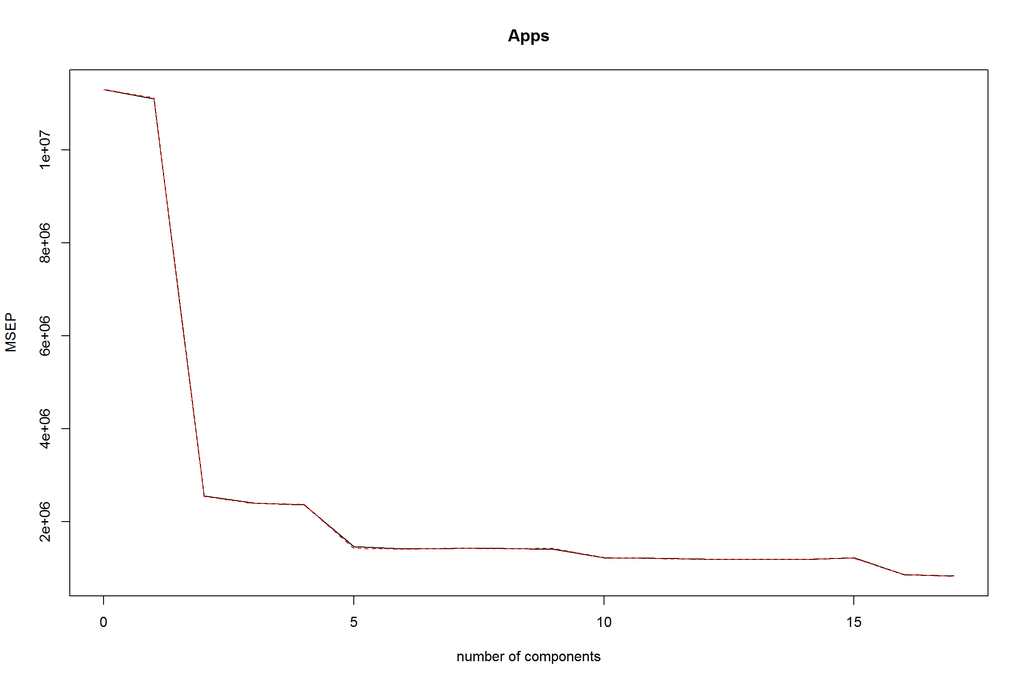

```
## Data:    X dimension: 388 17
##  Y dimension: 388 1
## Fit method: svdpc
## Number of components considered: 17
##
## VALIDATION: RMSEP
## Cross-validated using 10 random segments.
##        (Intercept)  1 comps  2 comps  3 comps  4 comps  5 comps  6 comps
## CV            4187     4187     2282     2288     2183     1919     1867
## adjCV         4187     4187     2277     2285     2300     1904     1860
##        7 comps  8 comps  9 comps  10 comps  11 comps  12 comps  13 comps
## CV        1827     1781     1784      1776      1777      1772      1771
## adjCV     1822     1773     1776      1769      1764      1765      1765
##        14 comps  15 comps  16 comps  17 comps
## CV         1772      1736      1363      1129
## adjCV      1782      1720      1342      1120
##
## TRAINING: % variance explained
##       1 comps  2 comps  3 comps  4 comps  5 comps  6 comps  7 comps
## X     33.2060    59.24    66.01     71.4    76.65    81.38    84.86
## Apps   0.3317    71.69    71.69     71.7    80.74    82.19    82.83
##       8 comps  9 comps  10 comps  11 comps  12 comps  13 comps  14 comps
## X       88.05    90.86     93.11     95.03     96.93     97.83     98.61
## Apps    84.05    84.22     84.27     84.64     84.69     84.90     85.64
##       15 comps  16 comps  17 comps
## X        99.27     99.80    100.00
## Apps     90.24     93.59     94.54
```

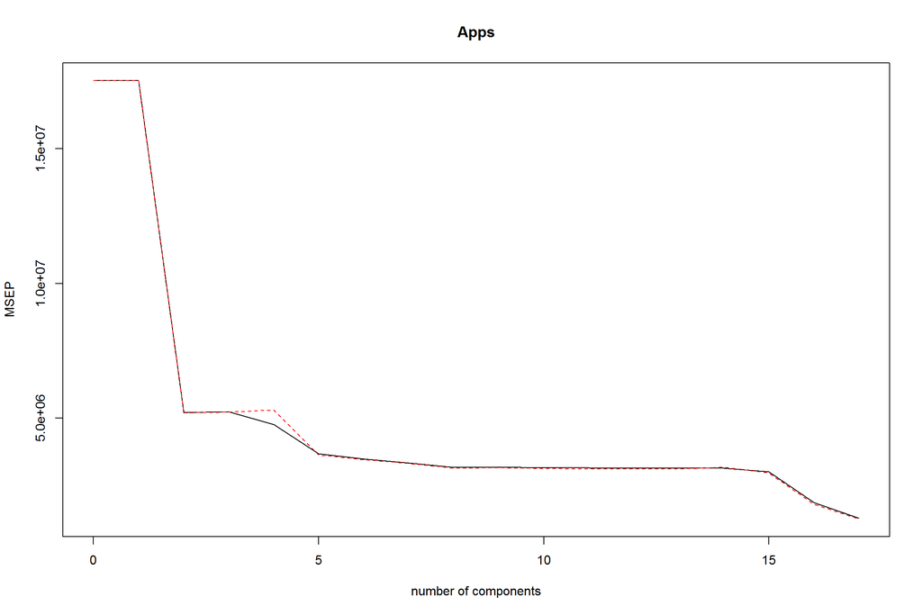

```
## Data:    X dimension: 388 17
##  Y dimension: 388 1
## Fit method: svdpc
## Number of components considered: 17
##
## VALIDATION: RMSEP
## Cross-validated using 10 random segments.
##        (Intercept)  1 comps  2 comps  3 comps  4 comps  5 comps  6 comps
## CV            3348     3359     1652     1514     1235     1191     1179
## adjCV         3348     3359     1647     1506     1214     1186     1171
##        7 comps  8 comps  9 comps  10 comps  11 comps  12 comps  13 comps
## CV        1151     1147     1072      1075      1072      1078      1082
## adjCV     1139     1137     1069      1071      1068      1074      1078
##        14 comps  15 comps  16 comps  17 comps
## CV         1084      1092     871.9     852.4
## adjCV      1080      1088     867.6     846.0
##
## TRAINING: % variance explained
##       1 comps  2 comps  3 comps  4 comps  5 comps  6 comps  7 comps
## X     32.3271    56.98    63.59    69.57    74.82    80.01    83.88
## Apps   0.1176    76.84    82.04    88.65    88.77    89.11    89.87
##       8 comps  9 comps  10 comps  11 comps  12 comps  13 comps  14 comps
## X       87.29    90.54     93.10     95.16     97.09     98.04     98.93
## Apps    89.95    90.61     90.67     90.72     90.72     90.73     90.82
##       15 comps  16 comps  17 comps
## X        99.45     99.83     100.0
## Apps     90.93     94.28      95.1
```

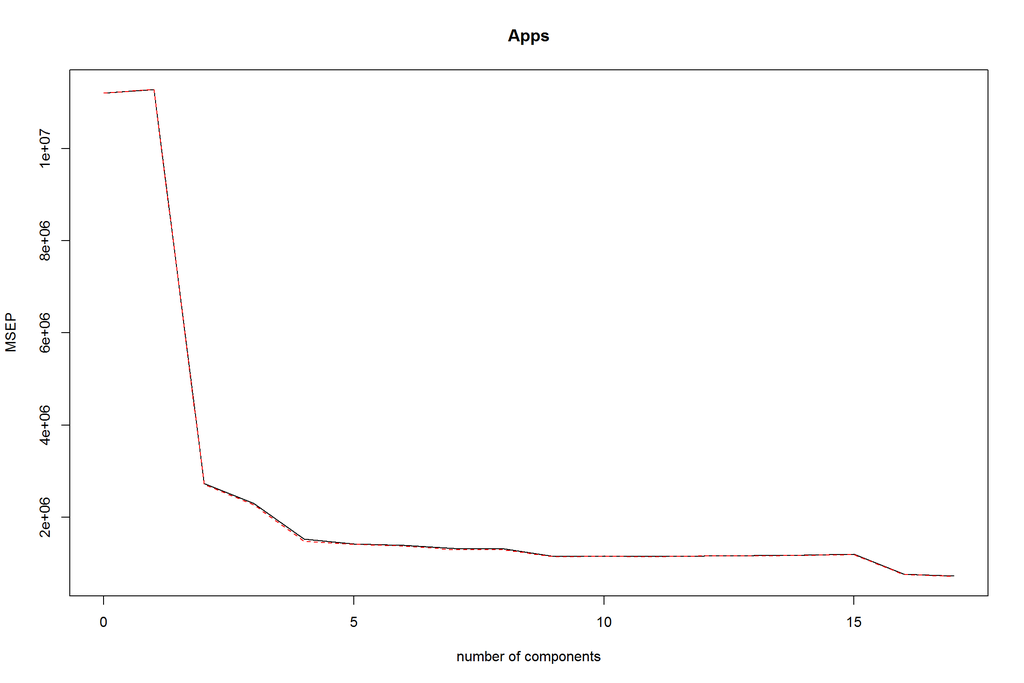

```
## The test error with PCR Regression was was: 1224.09 with m = 17
```

The test error using Principal Component regression was was:1224.09 with number of components = 17

### 3.f

```
##     Private        Apps      Accept      Enroll   Top10perc   Top25perc
##           0           0           0           0           0           0
## F.Undergrad P.Undergrad    Outstate  Room.Board       Books    Personal
##           0           0           0           0           0           0
##         PhD    Terminal   S.F.Ratio perc.alumni      Expend   Grad.Rate
##           0           0           0           0           0           0
```

```
## Data:    X dimension: 388 17
##  Y dimension: 388 1
## Fit method: kernelpls
## Number of components considered: 17
##
## VALIDATION: RMSEP
## Cross-validated using 10 random segments.
##        (Intercept)  1 comps  2 comps  3 comps  4 comps  5 comps  6 comps
## CV            4335     2176     1888     1734     1605     1400     1311
## adjCV         4335     2171     1882     1724     1571     1373     1295
##        7 comps  8 comps  9 comps  10 comps  11 comps  12 comps  13 comps
## CV        1297     1287     1278      1278      1277      1281      1281
## adjCV     1281     1273     1265      1265      1264      1267      1268
##        14 comps  15 comps  16 comps  17 comps
## CV         1283      1284      1285      1285
## adjCV      1270      1271      1271      1272
##
## TRAINING: % variance explained
##       1 comps  2 comps  3 comps  4 comps  5 comps  6 comps  7 comps
## X       26.91    43.08    63.26    65.16    68.50    73.75    76.10
## Apps    76.64    83.93    87.14    91.90    93.49    93.85    93.91
##       8 comps  9 comps  10 comps  11 comps  12 comps  13 comps  14 comps
## X       79.03    81.76     85.41     89.03     91.38     93.31     95.43
## Apps    93.94    93.96     93.96     93.96     93.97     93.97     93.97
##       15 comps  16 comps  17 comps
## X        97.41     98.78    100.00
## Apps     93.97     93.97     93.97
```

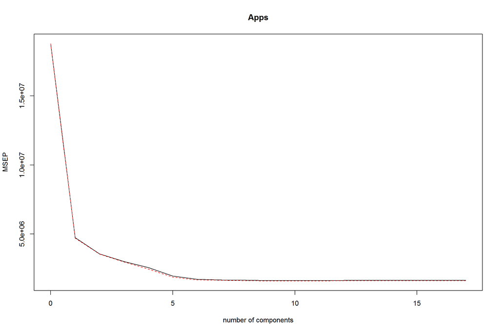

```
## Data:    X dimension: 388 17
##  Y dimension: 388 1
## Fit method: kernelpls
## Number of components considered: 17
##
## VALIDATION: RMSEP
## Cross-validated using 10 random segments.
##        (Intercept)  1 comps  2 comps  3 comps  4 comps  5 comps  6 comps
## CV            3508     1543     1172     1178     1173     1132     1091
## adjCV         3508     1538     1145     1174     1163     1115     1083
##        7 comps  8 comps  9 comps  10 comps  11 comps  12 comps  13 comps
## CV        1088     1079     1073      1070      1070      1073      1072
## adjCV     1081     1073     1067      1064      1064      1066      1066
##        14 comps  15 comps  16 comps  17 comps
## CV         1072      1073      1073      1073
## adjCV      1065      1066      1066      1067
##
## TRAINING: % variance explained
##       1 comps  2 comps  3 comps  4 comps  5 comps  6 comps  7 comps
## X       25.81    32.40    63.00    66.40    68.58    73.09    77.67
## Apps    82.01    89.71    90.03    90.94    91.96    92.31    92.44
##       8 comps  9 comps  10 comps  11 comps  12 comps  13 comps  14 comps
## X       81.56    83.39     86.04     89.17      91.3     93.59     94.78
## Apps    92.49    92.53     92.56     92.58      92.6     92.61     92.61
##       15 comps  16 comps  17 comps
## X        97.58     98.19    100.00
## Apps     92.61     92.61     92.61
```

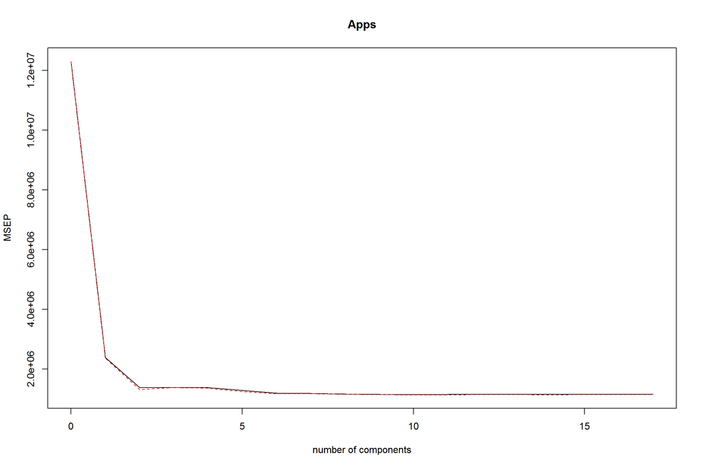

```
## Data:    X dimension: 388 17
##  Y dimension: 388 1
## Fit method: kernelpls
## Number of components considered: 17
##
## VALIDATION: RMSEP
## Cross-validated using 10 random segments.
##        (Intercept)  1 comps  2 comps  3 comps  4 comps  5 comps  6 comps
## CV            3363     1451     1148     1068     1027    998.7    927.8
## adjCV         3363     1447     1146     1067     1023    995.7    922.7
##        7 comps  8 comps  9 comps  10 comps  11 comps  12 comps  13 comps
## CV       922.7    918.1    915.9     913.7     911.6     907.7     909.0
## adjCV    918.8    914.6    912.6     910.4     908.6     904.8     906.1
##        14 comps  15 comps  16 comps  17 comps
## CV        909.0     908.9     909.0     909.1
## adjCV     906.1     905.9     906.1     906.1
##
## TRAINING: % variance explained
##       1 comps  2 comps  3 comps  4 comps  5 comps  6 comps  7 comps
## X       26.68    39.01    62.61    66.47    71.18    72.72    76.72
## Apps    82.34    88.83    90.48    91.69    92.34    93.32    93.42
##       8 comps  9 comps  10 comps  11 comps  12 comps  13 comps  14 comps
## X       80.20    83.34     85.64     88.81     90.50     93.58     95.66
## Apps    93.47    93.48     93.50     93.51     93.53     93.53     93.53
##       15 comps  16 comps  17 comps
## X        97.27     99.30    100.00
## Apps     93.53     93.53     93.53
```

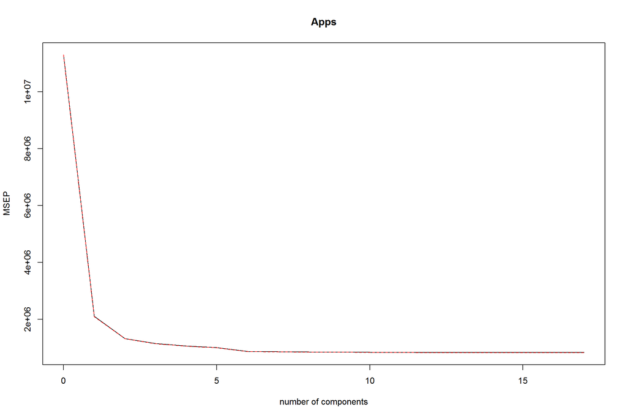

```
## Data:    X dimension: 388 17
##  Y dimension: 388 1
## Fit method: kernelpls
## Number of components considered: 17
##
## VALIDATION: RMSEP
## Cross-validated using 10 random segments.
##        (Intercept)  1 comps  2 comps  3 comps  4 comps  5 comps  6 comps
## CV            4187     2110     1743     1694     1563     1273     1208
## adjCV         4187     2104     1728     1683     1531     1247     1193
##        7 comps  8 comps  9 comps  10 comps  11 comps  12 comps  13 comps
## CV        1184     1169     1143      1141      1130      1129      1129
## adjCV     1170     1155     1133      1131      1121      1120      1120
##        14 comps  15 comps  16 comps  17 comps
## CV         1130      1129      1129      1129
## adjCV      1121      1121      1120      1120
##
## TRAINING: % variance explained
##       1 comps  2 comps  3 comps  4 comps  5 comps  6 comps  7 comps
## X       25.95    34.42    63.92    66.23    68.64    72.27    74.92
## Apps    76.46    86.04    87.38    91.98    93.95    94.17    94.30
##       8 comps  9 comps  10 comps  11 comps  12 comps  13 comps  14 comps
## X        78.7    82.39     85.10     86.72     90.80     93.76     95.19
## Apps     94.4    94.48     94.51     94.54     94.54     94.54     94.54
##       15 comps  16 comps  17 comps
## X        97.28     98.17    100.00
## Apps     94.54     94.54     94.54
```

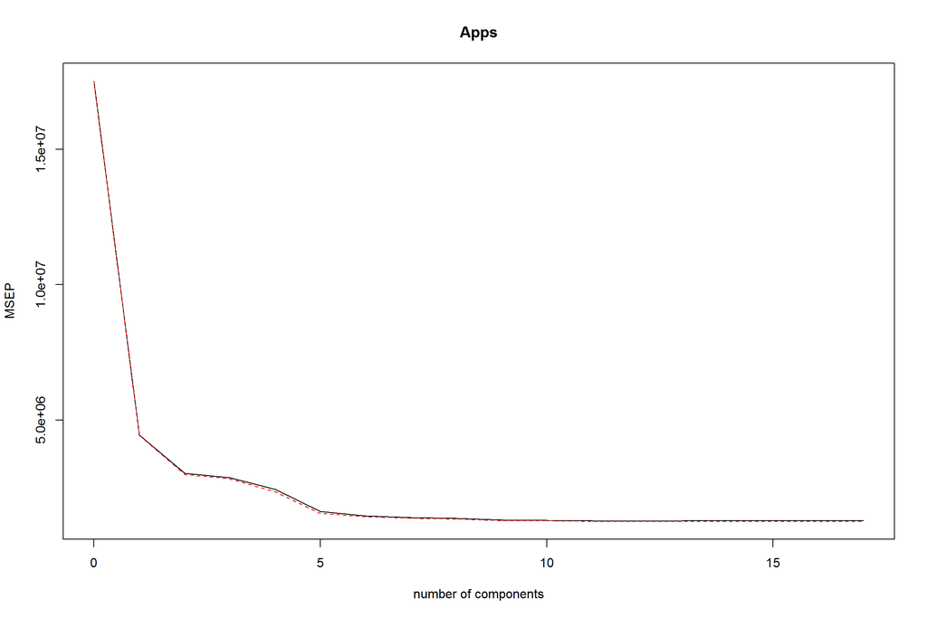

```
## Data:    X dimension: 388 17
##  Y dimension: 388 1
## Fit method: kernelpls
## Number of components considered: 17
##
## VALIDATION: RMSEP
## Cross-validated using 10 random segments.
##        (Intercept)  1 comps  2 comps  3 comps  4 comps  5 comps  6 comps
## CV            3348     1434     1049     1021     1033    935.5    866.6
## adjCV         3348     1429     1043     1022     1025    927.0    860.1
##        7 comps  8 comps  9 comps  10 comps  11 comps  12 comps  13 comps
## CV       857.1    851.3    853.2     856.9     855.1     854.6     853.6
## adjCV    851.2    845.7    847.3     850.6     848.3     848.0     847.1
##        14 comps  15 comps  16 comps  17 comps
## CV        852.0     852.2     852.4     852.4
## adjCV     845.7     845.9     846.0     846.0
##
## TRAINING: % variance explained
##       1 comps  2 comps  3 comps  4 comps  5 comps  6 comps  7 comps
## X       24.48    31.85    62.50    66.71    69.79    73.37    76.82
## Apps    82.87    90.86    91.25    92.46    94.04    94.80    94.90
##       8 comps  9 comps  10 comps  11 comps  12 comps  13 comps  14 comps
## X       80.01    82.60     84.78     86.06     89.22     93.08     94.69
## Apps    94.96    95.02     95.06     95.09     95.10     95.10     95.10
##       15 comps  16 comps  17 comps
## X        97.05     99.03     100.0
## Apps     95.10     95.10      95.1
```

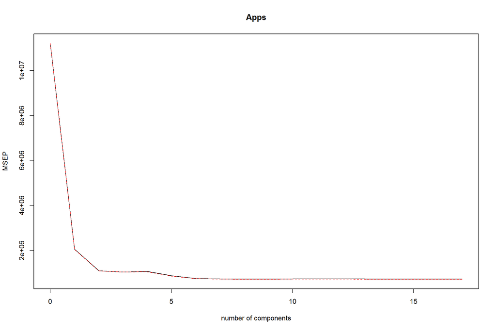

```
## The test error with PLS Regression was was: 1228.55 with m = 17
```

### 3.g

| Regression type | Root Mean Square error |
| --- | --- |
| Ordinary Least Squares | 1303 |
| Ridge regression | 1220 |
| Lasso regression | 1241 |
| PCR Model | 1224 |
| PLS Model | 1229 |

Since the average root mean square errors we have obtained in the models are between 1050 - 1350, our predictions are usually off by around a 1000 applications. The high RMSE can be explained because of some colleges taking in close to 48,000 applications (in which case an error rate of around a 1000 is reasonable), while some take in just 100.